# Estadística Descriptiva Multivariada

Análisis de Componentes Principales

Jimmy A Corzo S, PhD

jacorzos@unal.edu.co

Giovany Babativa-Márquez, PhD

jgbabativam@unal.edu.co

# Análisis de Componentes Principales

## Contenido

# Descripción del método

## Dos enfoques de las componentes principales

### Enfoque estadístico

Buscar ponderaciones $v_1, \ldots, v_p$ de combinaciones lineales de las variables originales que **maximizan la varianza** de las proyecciones.

- Las ponderaciones se construyen de forma que las componentes sean **ortogonales** entre sí.
- Las componentes resultantes son **no correlacionadas**.

### Enfoque de aprendizaje estadístico

Problema de optimización que **minimiza la suma de cuadrados residuales** entre los datos originales y su aproximación de rango reducido.

- Se busca la proyección de los datos sobre un subespacio de dimensión $q < p$.
- La solución proviene del Teorema de Descomposición en Valores Singulares (**TDVS**).

> **Conclusión:** Ambos enfoques producen exactamente la misma solución. El TDVS garantiza la equivalencia mediante los valores y vectores propios de $X^\prime X$ y $XX^\prime$.

## Dos enfoques de las componentes principales

Pearson (1901) planteó un problema geométrico: encontrar una representación óptima de datos multivariados en una dimensión reducida con respecto al error cuadrático medio.

Sea $\mathbf{X}\in \mathbb{R}^{n \times p}$ una matriz centrada, el problema del ACP es

$$\min_{V \in \mathbb{R}^{p \times k}}
\sum_{i=1}^{n} \left\| \mathbf{x}_i - V V^\prime \mathbf{x}_i \right\|^2
\quad \text{s.a.} \quad V^\prime V = I_k, \quad k < p$$

Equivalente a:

$$\min_{V^\prime V = I_k} \left\|\mathbf{X} - \mathbf{X} V V^\prime \right\|_F^2$$

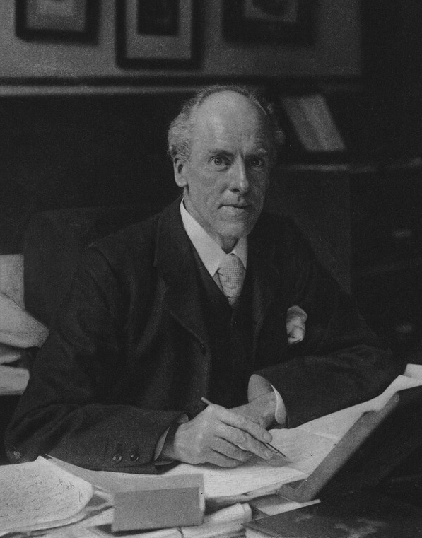

## Dos enfoques de las componentes principales

Hotelling (1933) mostró que las cargas de los componentes principales son los eigenvectores de la matriz de covarianza muestral.

El objetivo del PCA puede escribirse como:

$$\max_{V \in \mathbb{R}^{p \times k}}
\operatorname{tr}\!\left( V^\prime S V \right),
\quad \text{s.a.} \quad V^\prime V = I_k, \quad k<p$$

donde

$$S = \frac{1}{n} X^\prime X$$

es la matriz de covarianza muestral y $X \in \mathbb{R}^{n \times p}$ es una matriz centrada.

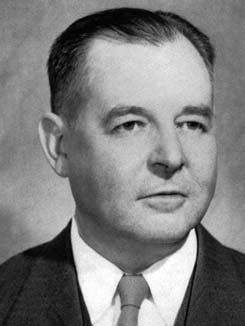

## Dos enfoques de las componentes principales

Enfoque de Hotelling (1933) vs Pearson (1901)

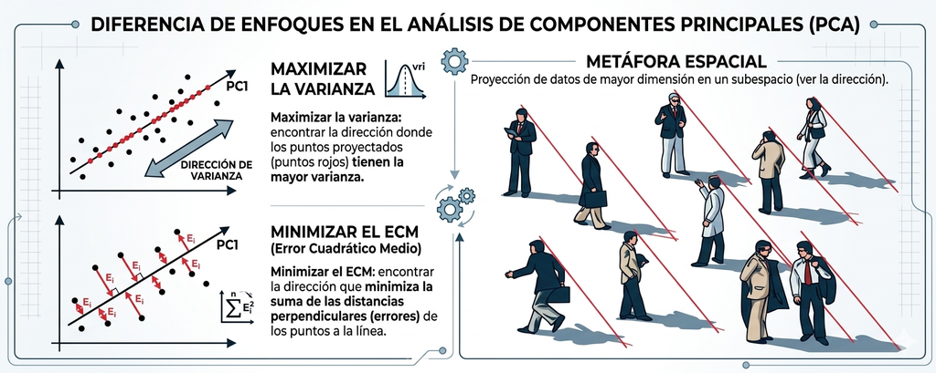

## Descripción del método

El **Análisis de Componentes Principales (ACP)** produce combinaciones lineales de las variables originales, denominadas:

> *componentes principales*, *factores* o *dimensiones*
- **Reducción de dimensiones:** representar $p$ variables en $q \ll p$ componentes con mínima pérdida de información.
- **Visualización de tablas:** proyectar objetos y variables sobre planos factoriales interpretables.
- **Análisis y comprensión:** identificar la estructura de correlaciones entre variables.
- **Imputación de datos faltantes:** usar las componentes como base para imputar.
- **Predictores para regresión:** solución a la multicolinealidad entre covariables.

## Utilidad del ACP

El ACP es la base de los **métodos factoriales** más importantes:

- **ACS** – Análisis de Correspondencias Simples: tablas de contingencia entre dos variables cualitativas.
- **ACM** – Análisis de Correspondencias Múltiples: tablas de individuos × variables cualitativas.
- **AFMG** – Análisis Factorial Múltiple Generalizado: tablas de individuos × bloques de variables.
- **STATIS**: tablas de tres índices (individuos × variables × condiciones).
- **Agrupamiento jerárquico:** el ACP es el preprocesamiento más común antes de clusterizar.

**Note**

El ACP es un método **no supervisado**: no existe una variable respuesta $Y$. El objetivo es explorar la estructura de los datos, no predecir.

# Fundamentos matemáticos

## Matriz de datos centrados, estandarizados y normados

Partiendo de la matriz de datos centrada y estandarizada $\widetilde{Y}$ (con denominador $\sqrt{n}$), se define:

$$Y = \frac{1}{\sqrt{n}}\,\widetilde{Y} = \frac{1}{\sqrt{n}}\,\widetilde{X}\,D^{-1/2}$$

donde $D = \text{diag}(s_1, \ldots, s_p)$ contiene las desviaciones estándar.

**Propiedades:**

$$\text{med}(Y) = \frac{1}{\sqrt{n}} med(\tilde{Y}) = \mathbf{0}$$

$$S_Y = Y^\prime Y = \frac{1}{n}\,\widetilde{Y}^\prime\widetilde{Y} = R$$

La matriz de covarianzas de $Y$ **coincide** con la matriz de correlaciones $R$.

## Aplicación del TDVS

Aplicando el Teorema de Descomposición en Valores Singulares a $Y$:

$$Y_{n \times p} = U_{n \times p}\; L_{p \times p}\; V_{p \times p}^\prime$$

donde:

| Objeto | Descripción |
| --- | --- |
| $U$ | columnas ortonormales: $U^\prime U = I_p$, **direcciones en espacio de objetos** |
| $V$ | columnas ortonormales: $V^\prime V = I_p$, **direcciones en espacio de variables** (cargas/loadings) |
| $L = \text{diag}(\sqrt{\lambda_1}, \ldots, \sqrt{\lambda_p})$ | valores singulares, con $\lambda_1 \ge \cdots \ge \lambda_p \ge 0$ |

Los $\lambda_\alpha$ son los valores propios de $Y^\prime Y = R$, y las columnas de $V$ son sus vectores propios. $\lambda_\alpha$ también son los valores propios de $YY^\prime$ y $U$ contiene en sus columnas sus vectores propios.

## Matriz de componentes principales

La **matriz de scores** (coordenadas de los objetos sobre las componentes) se obtiene como:

$$Z = Y\,V$$

La $\alpha$-ésima componente principal es:
$$z_\alpha = Y\,v_\alpha = \sqrt{\lambda_\alpha}\,u_\alpha$$

donde $v_\alpha$ es la $\alpha$-ésima columna de $V$ (vector de cargas) y $u_\alpha$ es la $\alpha$-ésima columna de $U$.

La **coordenada** del objeto $i$ sobre la componente $\alpha$ es:
$$z_{i\alpha} = y_{i\cdot}^\prime v_\alpha = \sum_{j=1}^p y_{ij}\, v_{j\alpha}$$

## Propiedades de las componentes principales

Las columnas de $Z = YV$ satisfacen:

**1. Media cero:**
$$\frac{1}{n}Z^\prime\mathbf{1}_n = \frac{1}{n}V^\prime Y^\prime \mathbf{1}_n = V^\prime \text{med}(Y) = \mathbf{0}$$

**2. Incorrelacionadas:**
$$Z^\prime Z = V^\prime Y^\prime Y V = V^\prime R\, V = \Lambda = \text{diag}(\lambda_1, \ldots, \lambda_p)$$

**Important**

Las componentes principales son combinaciones lineales **no correlacionadas** y sus varianzas son los valores propios de $R$. La varianza de $Z_\alpha$ es exactamente $\lambda_\alpha$.

## Análisis para los objetos

El objeto $i$ queda representado en el plano factorial por el vector de coordenadas:

$$z_{i\cdot} = \left(z_{i1}, \ldots, z_{i\alpha}, \ldots, z_{ip}\right)$$

La varianza de la $\alpha$-ésima componente en el conjunto de $n$ objetos es:

$$\text{var}(Z_\alpha) = v_\alpha^\prime Y^\prime Y\, v_\alpha = v_\alpha^\prime R v_\alpha = \lambda_\alpha v_\alpha^\prime v_\alpha = \lambda_\alpha$$

**Interpretación:** $v_1$ es la dirección de máxima varianza en el espacio de las variables; $v_2$ es la dirección de máxima varianza **ortogonal a** $v_1$; y así sucesivamente.

## Análisis para las variables

De $Y = ULV^\prime$ se obtiene $Y^\prime = VLU^\prime$. Proyectando las variables sobre el espacio de objetos:

$$W = Y^\prime U = VL$$

La $\alpha$-ésima componente es $w_\alpha = Y^\prime u_\alpha$ y la coordenada de la variable $j$ sobre la componente $\alpha$:

$$w_{j\alpha} = \sum_{i=1}^n u_{i\alpha}\, y_{ij}$$

Las columnas de $W$ describen cómo cada variable se **asocia** con cada dirección principal. La distancia de la variable $j$ al origen en el plano 1-2 mide cuánto de su varianza es capturada por esas dos componentes.

## Proporción de varianza explicada

La **varianza total** de los datos estandarizados es $\text{tr}(R) = p$.

La proporción de varianza capturada por las primeras $q$ componentes es:

$$\tau_q = \frac{\sum_{\alpha=1}^q \lambda_\alpha}{\sum_{\alpha=1}^p \lambda_\alpha} = \frac{\sum_{\alpha=1}^q \lambda_\alpha}{p}$$

**Criterios para elegir $q$:**

1. **Porcentaje acumulado:** retener componentes hasta alcanzar un umbral prefijado (p.ej., 70–80 %).
2. **Valor propio mayor que 1:** retener $\lambda_\alpha > 1$ (regla de Kaiser). Solo aplica cuando se trabaja con $R$.
3. **Gráfico de sedimentación (scree plot):** buscar el “codo” en la curva de valores propios.

## Ecuaciones de transición (I)

Los vectores propios de $Y^\prime Y$ y $YY^\prime$ comparten los valores propios.

Sea $v_\alpha$ vector propio de $R = Y^\prime Y$ con valor propio $\lambda_\alpha$:

$$Y^\prime Y\, v_\alpha = \lambda_\alpha\, v_\alpha$$

Multiplicando por $Y$ a la izquierda:

$$Y Y^\prime (Y v_\alpha) = \lambda_\alpha (Y v_\alpha)$$

> $Y v_\alpha$ es vector propio de $YY^\prime$ **con el mismo valor propio** $\lambda_\alpha$. Las matrices $Y^\prime Y$ y $YY^\prime$ comparten todos sus valores propios no nulos.

## Ecuaciones de transición (II)

La norma de $Yv_\alpha$ es:

$$\|Yv_\alpha\| = \sqrt{v_\alpha^\prime Y^\prime Y v_\alpha} = \sqrt{\lambda_\alpha}$$

Por tanto, el vector normalizado en el espacio de objetos es:

$$u_\alpha = \frac{1}{\sqrt{\lambda_\alpha}}\,Y v_\alpha$$

Y recíprocamente:

$$v_\alpha = \frac{1}{\sqrt{\lambda_\alpha}}\,Y^\prime u_\alpha$$

## Ecuaciones de transición (III)

Sustituyendo $v_\alpha = \frac{1}{\sqrt{\lambda_\alpha}} Y^\prime u_\alpha$ en $z_\alpha = Yv_\alpha$:

$$z_\alpha = Y v_\alpha = \frac{1}{\sqrt{\lambda_\alpha}}\,YY^\prime u_\alpha = \frac{\lambda_\alpha}{\sqrt{\lambda_\alpha}}\,u_\alpha = \sqrt{\lambda_\alpha}\,u_\alpha$$

> **Conclusión clave:** Basta calcular los vectores propios de $R = Y^\prime Y$ para obtener los del espacio de objetos, y viceversa. En la práctica, se elige la descomposición más eficiente según las dimensiones de la tabla ($n$ vs $p$).

# Construcción de las componentes

## Método de multiplicadores de Lagrange

El **primer vector de cargas** $v_1$ es la solución del problema de optimización:

$$\max_{v_1} \quad v_1^\prime R\, v_1 \qquad \text{sujeto a} \quad v_1^\prime v_1 = 1$$

El Lagrangiano del problema es:

$$\mathcal{L} = v_1^\prime R\, v_1 - \lambda_1(v_1^\prime v_1 - 1)$$

Derivando e igualando a cero:

$$\frac{\partial \mathcal{L}}{\partial v_1} = 2R\,v_1 - 2\lambda_1 v_1 = 0 \implies R\,v_1 = \lambda_1\,v_1$$

> **Conclusión:** $\lambda_1$ y $v_1$ son el **valor propio mayor** y su **vector propio asociado** de $R$. Las componentes sucesivas se obtienen imponiendo ortogonalidad $v_j^\prime v_i = 0$ para $i < j$.

## Cálculo de las componentes principales

Ordenando los valores propios de $R$ de mayor a menor: $\lambda_1 \ge \lambda_2 \ge \cdots \ge \lambda_p \ge 0$, la $\alpha$-ésima componente principal es:

$$Z_\alpha = \widetilde{Y}\, v_\alpha = \sqrt{n}\; Y\, v_\alpha$$

con varianza $\text{var}(Z_\alpha) = \lambda_\alpha$.

**Propiedad fundamental — conservación de la varianza total:**

$$\text{tr}(R) = \sum_{j=1}^p s_j^2 = p = \sum_{\alpha=1}^p \lambda_\alpha$$

El ACP redistribuye la varianza total de las $p$ variables originales en $p$ componentes independientes, concentrando la mayor parte en las primeras.

# Guías para la interpretación

## Calidad de la representación global

La **calidad de representación** de un conjunto de $q$ componentes mide qué fracción de la varianza total captura la aproximación de rango $q$:

$$\tau_q = \frac{\sum_{\alpha=1}^q \lambda_\alpha}{p}$$

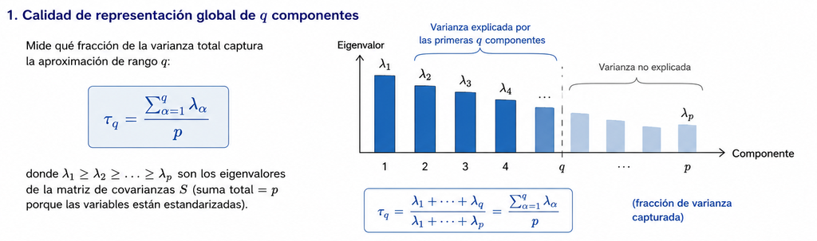

## Tres criterios para la interpretación de los factores

1. **Correlaciones variable-Factor**: Indican hasta dónde es capaz una variable de explicar o conformar el factor.
2. **Contribuciones**: Es el aporte de cada variable a la varianza del factor.
3. **Cosenos cuadrados (cos2)**: Indican hasta dónde un factor es capaz de dar cuenta de una variable.

## Interpretación de los factores

La **correlación** entre la variable $X_j$ y la componente $Z_\alpha$ es:

$$r(X_j, Z_\alpha) = \sqrt{\lambda_\alpha}\; v_{j\alpha}$$

**Interpretación:**

- Si $|r(X_j, Z_\alpha)|$ es alto, la variable $X_j$ tipifica bien la componente $\alpha$.
- Variables con alta correlación con la misma componente miden aspectos similares.
- Variables con correlaciones de signo opuesto están inversamente relacionadas.

En la práctica, en FactoMineR las coordenadas de las variables en el plano se obtienen directamente como $\sqrt{\lambda_\alpha}\; v_{j\alpha}$, lo que facilita la interpretación.

## Interpretación de los factores

La **contribución** de la variable $j$ a la componente $\alpha$ mide qué fracción de $\lambda_\alpha$ aporta esa variable:

$$\text{CTR}(j, \alpha) = \frac{v_{j\alpha}^2}{\sum_{k=1}^p v_{k\alpha}^2} = v_{j\alpha}^2$$

ya que $v_\alpha^\prime v_\alpha = 1$

Para los **objetos**, la contribución del objeto $i$ a la componente $\alpha$ es:

$$\text{CTR}(i, \alpha) = \frac{z_{i\alpha}^2}{\sum_{i^\prime=1}^n z_{i^\prime\alpha}^2} = \frac{z_{i\alpha}^2}{n\,\lambda_\alpha}$$

**Note**

Las contribuciones suman 1 sobre todas las variables (u objetos) para cada componente fija. Son útiles para identificar qué variables (u objetos) “definen” cada componente.

## Interpretación de los factores

Los **cosenos cuadrados** ($\cos^2$) miden la calidad de la representación de un objeto o variable en un plano factorial:

**Para las variables:**
$$\cos^2(\theta_{j,\alpha}) = \lambda_\alpha\, v_{j\alpha}^2 = r^2(X_j, Z_\alpha)$$

**Para los objetos:**
$$\cos^2(i, \alpha) = \frac{z_{i\alpha}^2}{\sum_{\beta=1}^p z_{i\beta}^2} = \frac{z_{i\alpha}^2}{\left\lVert z_i\right\rVert^2}$$

**Warning**

Una variable puede tener **alta contribución** a una componente pero **bajo cos²** en el plano si la norma de su vector de coordenadas es pequeña. Siempre se recomienda interpretar ambos indicadores conjuntamente.

## Ilustración contribuciones y cosenos cuadrados

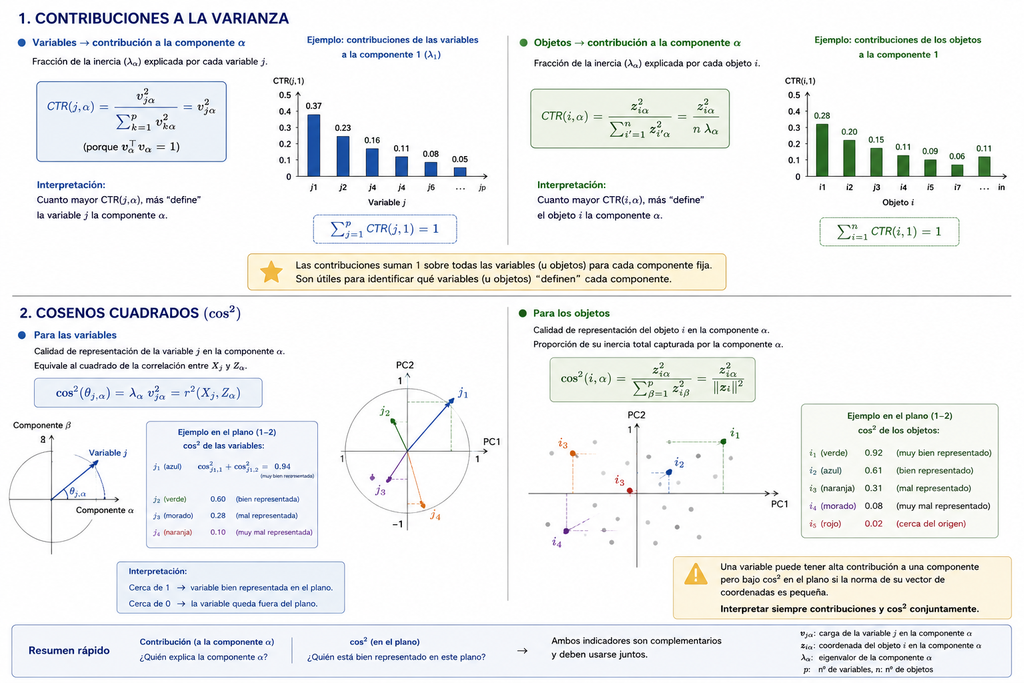

## Planos factoriales y distancias entre variables

Las variables se representan en el plano factorial como vectores desde el origen. La distancia entre dos variables en el espacio de $q$ componentes es:

$$d^2(X_j, X_{j^\prime}) = 2\left(1 - \cos\theta_{jj^\prime}\right)$$

donde $\theta_{jj^\prime}$ es el ángulo entre sus vectores en el plano.

| Ángulo | Coseno | Distancia | Interpretación |
| --- | --- | --- | --- |
| $0°$ | $+1$ | $0$ | Directamente correlacionadas |
| $90°$ | $0$ | $\sqrt{2}$ | Incorrelacionadas |
| $180°$ | $-1$ | $2$ | Inversamente correlacionadas |

## Planos factoriales y distancias entre variables

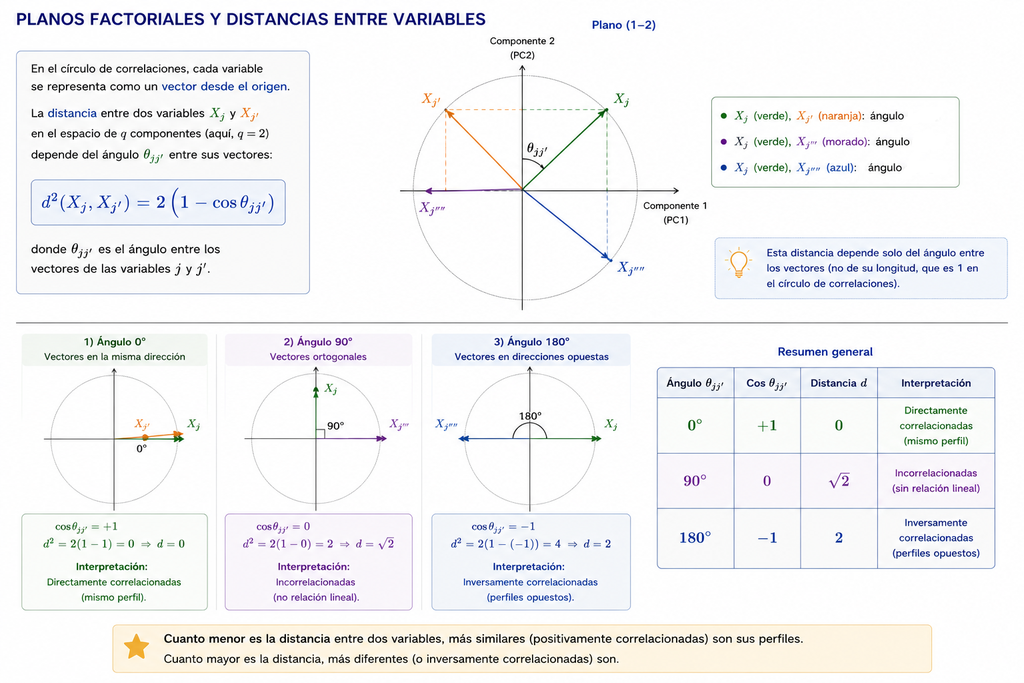

## Tipificación de los objetos

Para interpretar los objetos en el plano factorial se utilizan:

- **Coordenadas** ($z_{i\alpha}$): posición del objeto sobre cada componente. Objetos con coordenadas similares tienen perfiles similares.
- **Contribuciones** (CTR): objetos con CTR alta “definen” la componente.
- **Cosenos cuadrados**: mide si el objeto está bien representado en el plano.
- **Cuadrantes opuestos:** objetos en cuadrantes opuestos tienen perfiles antípodas.
- **Distancia al origen:** objetos lejos del origen tienen perfiles distintos al perfil medio.

### Tipificación de los objetos

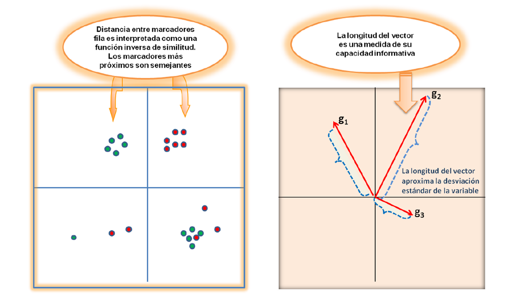

### Tipificación de los objetos

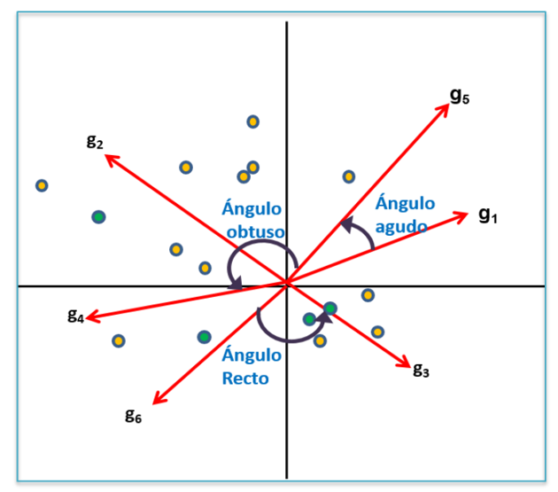

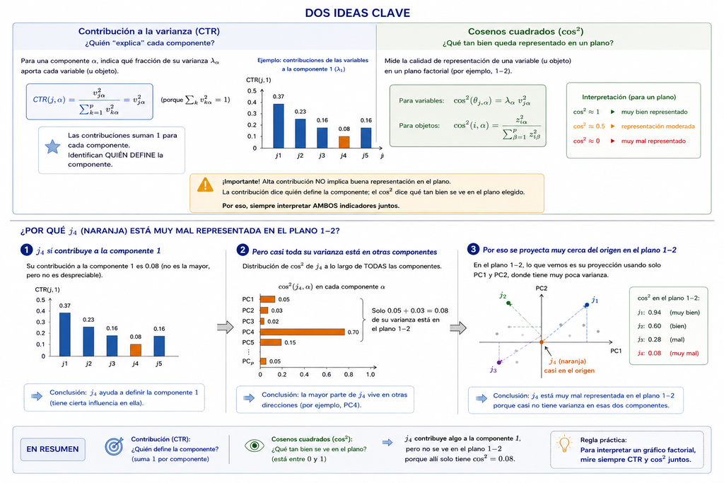

## Biplots: relaciones objeto-variable

El **biplot** representa simultáneamente objetos y variables en el mismo plano factorial.

- Los **objetos** aparecen como puntos.
- Las **variables** aparecen como vectores o flechas desde el origen.
- Un objeto cercano al extremo de una variable tiene un valor alto en esa variable.
- Un objeto opuesto al extremo de una variable tiene un valor bajo en ella.
- Variables con flechas en la misma dirección están correlacionadas positivamente.

**Note**

En el biplot de factoextra (`fviz_pca_biplot`), los vectores de las variables están escalados por $\sqrt{\lambda_\alpha}$, lo que facilita la interpretación simultánea.

## Factor tamaño y variables suplementarias

**Factor tamaño:** Cuando la primera componente está correlacionada con **todas** las variables, se interpreta como un indicador de “tamaño” o “nivel general”. Las componentes posteriores capturan contrastes (forma, estructura).

**Variables suplementarias (ilustrativas):**

Variables que no participan en el cálculo del ACP pero se **proyectan sobre el plano** para interpretar las componentes en términos de variables externas o validar el análisis.

```r
PCA(datos, quanti.sup = c(3, 5))   # columnas 3 y 5 como suplementarias
```

**Objetos suplementarios (ilustrativos):**

Objetos que no participan en el cálculo pero se proyectan para evaluar su similitud con los objetos activos.

```r
PCA(datos, ind.sup = c(1, 4, 7))   # filas 1, 4 y 7 como ilustrativas
```

# Ejemplo 1: Rankings universitarios latinoamericanos

## Descripción de los datos

Se dispone de tres rankings internacionales para universidades latinoamericanas:

| Ranking | Institución | Criterio principal |
| --- | --- | --- |
| **Scimago** | SCImago Research Group | Producción e impacto científico |
| **QS** | Quacquarelli Symonds | Reputación académica y empleabilidad |
| **Webometrics** | CSIC (España) | Presencia y visibilidad en internet |

Los datos corresponden a **promedios por país** de las posiciones de sus universidades (en negativo, para que mayor = mejor posición):

## Carga de los datos

```r
library(pacman)
p_load(tidyverse, FactoMineR, factoextra, janitor, corrplot)

url <- "https://github.com/jgbabativam/Curso_Multivariado/raw/main/Datos/"
rank_lat <- read.csv2(paste0(url, "r14_Sci_Qs_Webometrics.csv"))
```

| Pais | SC.Lac.Ranking | QS.Ranking | WEB.Ranking.LA |
| --- | --- | --- | --- |
| BRA | 1 | 2 | 1 |
| MEX | 2 | 8 | 2 |
| BRA | 4 | 3 | 8 |
| ARG | 7 | 19 | 7 |
| BRA | 5 | 4 | 5 |
| BRA | 3 | 9 | 11 |
| BRA | 6 | 10 | 3 |
| BRA | 8 | 10 | 9 |
| CHL | 10 | 6 | 6 |
| CHL | 13 | 1 | 24 |
| BRA | 9 | 15 | 54 |
| ARG | 15 | 21 | 18 |
| BRA | 11 | 41 | 4 |
| BRA | 24 | 34 | 35 |
| BRA | 19 | 17 | 13 |
| BRA | 21 | 18 | 43 |
| URY | 33 | 54 | 137 |
| BRA | 14 | 40 | 12 |
| BRA | 17 | 43 | 21 |
| CHL | 28 | 12 | 32 |
| COL | 47 | 5 | 38 |
| BRA | 22 | 100 | 17 |
| MEX | 16 | 26 | 23 |
| BRA | 29 | 73 | 14 |
| ARG | 30 | 25 | 19 |
| COL | 18 | 14 | 10 |
| BRA | 23 | 49 | 16 |
| PRI | 26 | 48 | 26 |
| MEX | 27 | 35 | 15 |
| BRA | 25 | 94 | 40 |

[output cut: 119 more lines]

## Preparación de los datos

Se analizan los promedios por país: columnas 2 (país) y 3-5 (rankings numéricos)

```r
rank <- rank_lat |>
        select(Pais, SC.Lac.Ranking, QS.Ranking, WEB.Ranking.LA) |>
        group_by(Pais) |>
        summarise(across(where(is.numeric), ~mean(., na.rm = T))) |>
        column_to_rownames("Pais") |>
        mutate(across(where(is.numeric), ~.*-1)) #Invertir escala

names(rank) <- c("SC_Lac", "QS", "WEB")
```

| País | SC_Lac | QS | WEB |
| --- | --- | --- | --- |
| ARG | -179.4 | -68.3 | -195.5 |
| BOL | -207.0 | -112.0 | -125.0 |
| BRA | -45.6 | -77.9 | -59.9 |
| CHL | -113.0 | -69.7 | -126.9 |
| COL | -169.1 | -63.9 | -143.9 |
| CRI | -96.5 | -38.5 | -61.0 |
| CUB | -77.0 | -91.0 | -60.0 |
| ECU | -240.0 | -100.7 | -121.3 |
| MEX | -96.3 | -79.3 | -101.2 |
| PAN | -281.0 | -110.5 | -285.5 |
| PER | -211.2 | -83.4 | -199.4 |
| PRI | -26.0 | -48.0 | -26.0 |
| PY | -253.0 | -78.0 | -204.0 |
| URY | -266.8 | -92.0 | -313.0 |
| VEN | -164.9 | -81.1 | -170.0 |

## Autovalores y varianza explicada

```r
pca_rank <- PCA(rank, graph = FALSE)
```

```r
fviz_eig(pca_rank, addlabels = TRUE, ylim = c(0, 100), barfill = "#0077b6", barcolor = "#0077b6", linecolor = "#C0392B") +
  labs(title = "Gráfico de sedimentación — Rankings latinoamericanos",
       x = "Componente", y = "% varianza explicada") + theme_bw()
```

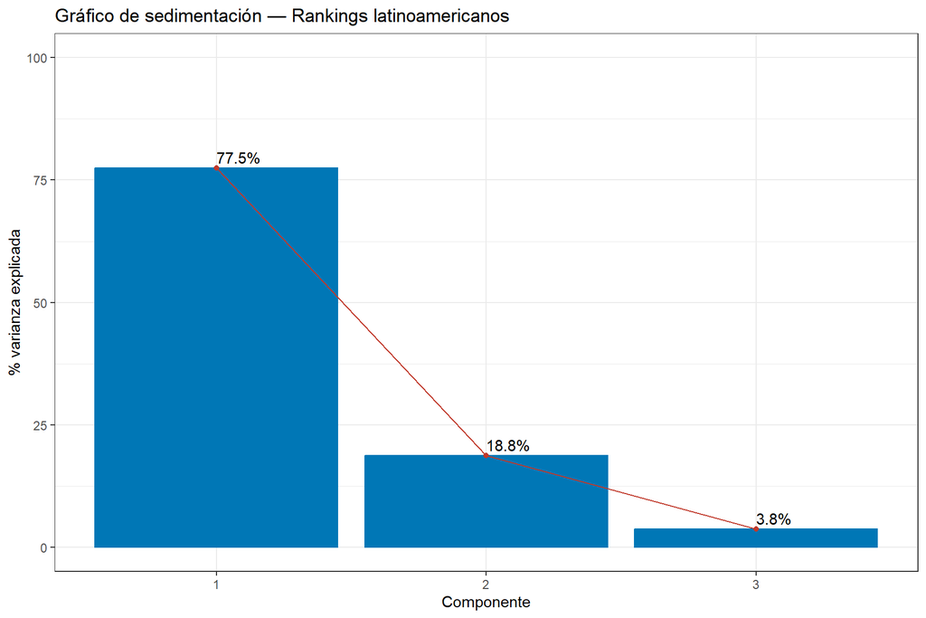

## Plano 1-2 de variables

```r
fviz_pca_var(pca_rank, col.var = "contrib",
             gradient.cols = c("#00AFBB", "#E7B800", "#FC4E07"),
             repel = TRUE, title = "Plano 1-2 — Variables (rankings)") + theme_bw()
```

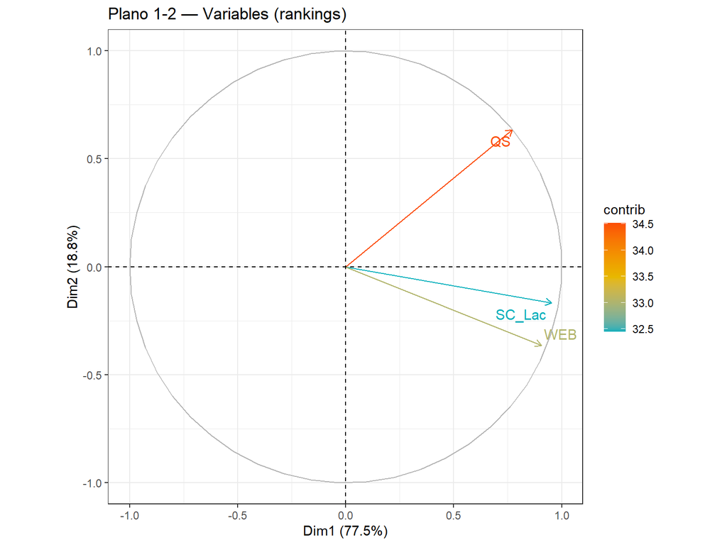

## Indicadores básicos — Variables

```r
res_var <- pca_rank$var
cat("=== Coordenadas (cargas × √λ) ===\n")
```

```
=== Coordenadas (cargas × √λ) ===
```

```r
round(res_var$coord, 3)
```

```
       Dim.1  Dim.2  Dim.3
SC_Lac 0.953 -0.167 -0.251
QS     0.771  0.634  0.058
WEB    0.906 -0.364  0.215
```

```r
cat("\n=== Contribuciones (%) ===\n")
```

```
=== Contribuciones (%) ===
```

```r
round(res_var$contrib, 2)
```

```
       Dim.1 Dim.2 Dim.3
SC_Lac 39.11  4.94 55.95
QS     25.57 71.49  2.94
WEB    35.32 23.57 41.11
```

```r
cat("\n=== Cosenos cuadrados ===\n")
```

```
=== Cosenos cuadrados ===
```

```r
round(res_var$cos2, 3)
```

```
       Dim.1 Dim.2 Dim.3
SC_Lac 0.909 0.028 0.063
QS     0.594 0.402 0.003
WEB    0.821 0.133 0.046
```

## Tipificación de los países

```r
fviz_pca_ind(pca_rank, col.ind = "cos2",
             gradient.cols = c("#00AFBB", "#E7B800", "#FC4E07"), repel = TRUE,
             title = "Plano 1-2 — Países (rankings universitarios)") + theme_bw()
```

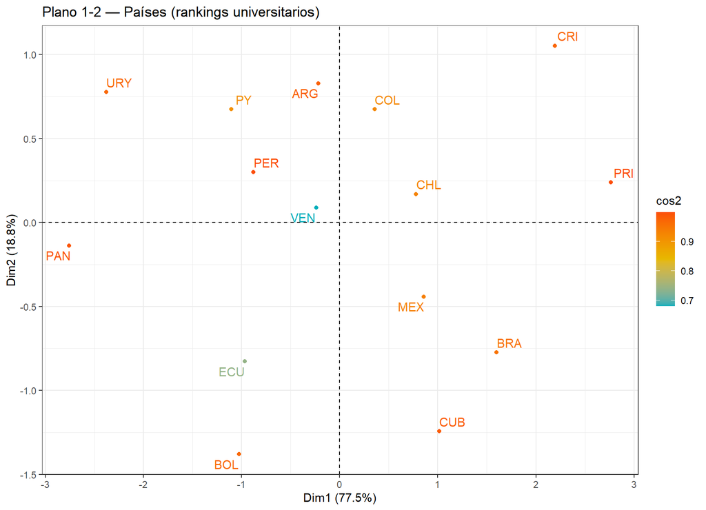